# Week1: Linear Models

### h) Repeat (a)–(f) after modifying the data generation process in such a way that there is less noise in the data. The model analyzed in this section,, should remain the same. You can do this by decreasing the variance of the normal distribution used to generate the error term ϵ in (b). Describe your results.

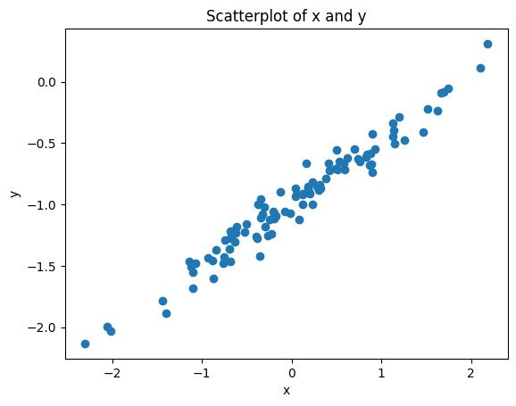

```
Intercept: -0.9852986470301799
Slope: 0.5095427133651171
```

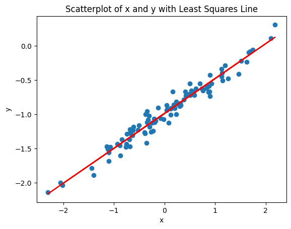

```python
# BEGIN SOLUTION
from sklearn.linear_model import LinearRegression
import numpy as np
import matplotlib.pyplot as plt


# To reduce noise we will reduce the scale
np.random.seed(1)
x = np.random.normal(loc=0, scale=1, size=100)
eps = np.random.normal(loc=0, scale=0.1, size=100)

beta_0 = -1
beta_1 = 0.5

y = beta_0 + beta_1 * x + eps

plt.scatter(x, y)
plt.xlabel('x')
plt.ylabel('y')
plt.title('Scatterplot of x and y')
plt.show()

# Reshape x to be a column vector
x = x.reshape(-1, 1)

# Fit the linear regression model
model = LinearRegression()
model.fit(x, y)

# Coefficients
intercept = model.intercept_
slope = model.coef_[0]

print("Intercept:", intercept)
print("Slope:", slope)

plt.scatter(x, y)
plt.plot(x, model.predict(x), color='red')
plt.xlabel('x')
plt.ylabel('y')
plt.title('Scatterplot of x and y with Least Squares Line')
plt.show()
# END SOLUTION
```

- Linear trend is being followed.
- intercept and slope is -0.9852986470301799 and 0.5095427133651171 respectively.
- Less noise in data and regression seems better fit.

### i) Repeat (a)–(f) after modifying the data generation process in such a way that there is more noise in the data. The model analyzed in this section ($Y = -1 + 0.5X + ϵ$) should remain the same. You can do this by increasing the variance of the normal distribution used to generate the error term $ϵ$ in (b). Describe your results.

```python
# BEGIN SOLUTION
np.random.seed(1)
x = np.random.normal(loc=0, scale=1, size=100)

# END SOLUTION
```

[output not shown]